# F1 Aus GP - GAD0001

### This report is available is a much better website at: shaunakgadkarigwsc.github.io/rscq/f1/

*Created by Shaunak Gadkari, Glen Waverley Secondary College 2019 - 9G1 using [Jupyter Notebook](https://jupyter.org/)*  
*Note: The programs in this report get data from various sets, you can find them [here](https://github.com/shaunakgadkarigwsc/shaunakgadkarigwsc.github.io/tree/master/rscq/f1/data/).*

## What will your flying vehicle’s power source be?

### Considerations

The engine’s safety is the most important factor. In fact, many rocket engines mounted onto manned capsules are often purposely limited in their power to stop them crushing the delicate humans inside with acceleration force. While actual figures vary due to the variation of body sizes and fat ratios which lead to inconsistent experimental results (as well as the ethical limitation of not being able to subject actual human bodies to considerable G forces), the morbidly named Euthanasia Coaster experiment [source 3] theorised via an experimental model that 1 minute of 10Gs of acceleration would be fatal to humans. 1G is 9.80665 m/s2 so we can show that 1 minute of approximately 98.0665m/s2 acceleration will kill. However, the real danger starts before that, especially with our task. Going up is much more dangerous because the blood flow to your brain is impeded by vertical acceleration. The human body can handle these high g-forces for a short amount of time - this is what makes rocket launches possible. However, within the scenario of this task, the person inside our car will have to take acceleration to extremely high speeds, as well as the horizontal force exerted when our car turns during laps. That is why it is important to consider the engine’s power and make appropriate strategies to handle the high speeds.

The engine’s weight and fuel consumption fall under the subcategory of mass – this is an extremely important factor as well. A conundrum with rocket science is that the more thrust you want, the more fuel you must put and the more powerful engine you must get. However, all this upgrading results in increased mass, requiring more thrust to lift, requiring more weight and so on. So, the obvious aim is to find a fuel efficient but still powerful engine. Luckily such engines are already being developed by companies such as NASA (SLR Launch System) and SpaceX (Merlin engines). Additionally, the engine must be able to run on small amounts of fuel over a long time – although it is true that cars with rocket engines have been developed, they cannot house enough fuel to last a standard Formula 1 race, only a large burst of speed at the start.

The engine’s scalability depends on whether it can be made smaller to fit onto a Formula 1 race car. It needs to be able to operate at the same relative efficiency even at the little sizes needed to be mounted onto a small vehicle.

The engine’s environmental footprint is important to reduce the impact that these races have on the environment. Cars and other assorted motor vehicles already are noticeably impacting the environment by releasing harmful exhaust gases into the air, and a major plus point for a propulsion method would be if it ran on a ‘green’ power source.

### Types of thrust

There are many different types of thrust available currently that can output enough power for out purposes. But selecting a specific subtype of thrust gives better control over accommodating for the factors mentioned above. There are two main types that are useful for this experiment:

#### Propeller thrust

Propeller thrust is used in many applications, such as motorboats and helicopters. It is when multiple angled blades are spun at a speed which causes them to create thrust via the pressure of the air being moved and Bernoulli’s principle which states that a fluid going over a curved surface will have less pressure that one going over a flat surface. Helicopters use this with blades mounted on top, in a configuration that provides downwards thrust and lifts the machine. Although this would help with the first part of our task - getting the car to fly - it isn’t designed for speed because only one blade assembly does the job of both upwards and forwards motion. Another idea is a front-facing assembly – like WW2 prop planes. However, a problem with this idea is that during ground driving the front facing propeller would be constantly scraped against the ground – not ideal. (Formula 1 cars’ suspension systems need to be low to reduce drag force). Also, it isn’t really sporting to have a giant death blade in the front of your car – this could cause problems for both the drivers and surrounding competitors. This system could work with electric power, which means that can be environmentally green. (Note: a fully solar powered propeller plane was developed a few years ago and completed a successful round-the-world tour)

#### Rocket thrust

With the recent increases in public interest in space, rocket technology has been advancing. Rockets are a high-powered way to turn chemical energy into (lots of) kinetic energy. Although the space-destined capsules that most rockets carry are much larger than our small Formula 1 race car, with enough money they can be adapted towards another weight profile. Rockets, by their concept, don’t work on environmentally green methods because they rely on burning fuel and releasing the exhaust into the environment. So, although in the future a ‘clean’ rocket propulsion method could be developed, rockets are currently not environmentally green.

#### Turbine thrust (subset of propeller thrust)

Modern jet aircraft use turbine engines to produce thrust in situations, usually where one single point of thrust (like in propeller or rocket thrust) is not useful. Jet turbines are a derivative of propeller-based thrust and use fans, driven by the burning of jet fuel, to produce backwards thrust (moving the plane forwards). These can also be driven by electricity but produce less power. Many military aircraft also use advanced configurations of these same base type of engine – for example some planes have mechanisms to angle them to lift straight up. For this method of propulsion to work, a plane (or car) must have wings to change the incoming air pressure into upwards force that will lift the vehicle. If this model is to be used, the wings that are designed will need to be extremely aerodynamically efficient but also able to be taken off (for ground-only flight). An advantage of this engine is that it is scalable – the turbines can be made smaller to fit onto a car and will then work on less fuel. In fact, it would be easier to build the smaller turbines if they ran on electric motors, which means this propulsion method can be adapted to be environmentally green.

### Propulsion Systems Summary (PROs and CONs)

```python
# Created by Shaunak Gadkari, 2019

# This is a python program that will print out data as a table on the different engine types
# NOTE: This code doesn't run on your computer, I ran it on mine and exported the results.

# Import 3rd party dependencies.
# This only needs to happen once.
import pandas as pd # Helps with plotting and graphing

# Plotly should be rendered inline in the notebook.
# plotly.offline.init_notebook_mode()

# Load a table on the comparison of different engine types
engine_comparison_data = pd.read_csv('data/01_engine_comparision.csv')

# Print the data table upto 10 rows (we have less than that)
engine_comparison_data.head(10)
```

|  | Type | Safety | Weight | Efficiency | Environmental Footprint | Scalability | Thrust Power |
| --- | --- | --- | --- | --- | --- | --- | --- |
| 0 | Propeller | Medium | Medium | Low | Low | Low | Low |
| 1 | Rocket | Low | High | High | High | Medium | High |
| 2 | Jet (Turbine) | Medium | Low | Medium | Low | High | Medium |

#### Propeller Powered Propulsion

- PRO: Environmentally green
- PRO: Somewhat easy to build
- PRO: Widely available
- CON: Not as efficient if scaled down
- CON: Not as good at forward thrust
- CON: Big and awkward

#### Rocket Powered Propulsion

- PRO: Very fast
- PRO: Good acceleration
- CON: Expensive and rare
- CON: Perhaps too much acceleration for humans
- CON: Not safe – once it’s lit, it’s lit
- CON: Not as efficient if scaled down
- CON: Not environmentally green

#### Jet Turbine Powered Propulsion

- PRO: Very scalable
- PRO: Widely available
- PRO: Can be adapted to be environmentally green
- PRO: Many configurations of this
- PRO: Configurable forwards and upwards thrust
- CON: Not as fast as the others

## Model of Jet Engine

I have researched models of small turbojet engines that could be used in the construction of a Formula 1 flying car. The results show that many models are available to perhaps use. As above, the important considerations needed in choosing a engine still apply.

**[Note: spec sheets for the engines are detailed in spec sheets 1, 2, 3, 4, 5, 6]**

### Table

*Note: not all jet engine specs have min/max fuel consumption and instead have specific fuel consumption. As such there is a column with 'Average/Calculated' fuel consumption that contains either the average of the minimum and the maximum or the calculated fuel consumption from the specific fuel consumption.*

```python
# Created by Shaunak Gadkari, 2019

# This is a python program that will print out data as a table on the different jet engine models
# NOTE: This code doesn't run on your computer, I ran it on mine and exported the results.

# Load a table on the comparison of different jet engine models
# NOTE: The reason I skipped to 07 is because I had previously collected information on many other models but then
# realised that they wouldn't be enough to lift the craft. They are included at data/02_jet_models.csv for comparison
# but not in this report.
jet_models_comparison_data = pd.read_csv('data/07_engine_comparison_diverse.csv')

# Render the data table upto 20 rows
jet_models_comparison_data.head(20)
```

|  | Model | Producer | Suited to? | Max Thrust (N) | Weight (kg) | Diameter (mm) | Length (mm) | Volume (cm^3) | Min FC (kg/hr) | Max FC (kg/hr) | Calculated/Average FC (kg/hr) | Specific FC (kg/kg/hr) |
| --- | --- | --- | --- | --- | --- | --- | --- | --- | --- | --- | --- | --- |
| 0 | DGEN-380 | Price Induction | Vertical takeoff/landing | 2550 | 80.00 | 469 | 1126 | 194524.343100 | NaN | NaN | 102.5641026 | 0.780000 |
| 1 | TJ23U | PBS Velka Bites | Maneuvering | 230 | 1.98 | 121 | 316 | 3633.688585 | 5.859000 | 30.225000 | 18.042 | 0.109744 |
| 2 | TJ40-G1 | PBS Velka Bites | Land acceleration | 395 | 3.30 | 147 | 304 | 5159.387350 | 10.695000 | 58.590000 | 34.6425 | 0.095259 |
| 3 | TJ40-G2 | PBS Velka Bites | Land acceleration | 395 | 3.80 | 147 | 373 | 6330.432504 | 294.365112 | 13.687978 | 154.0265446 | 0.024671 |
| 4 | TJ100 | PBS Velka Bites | Land acceleration | 1300 | 19.50 | 272 | 625 | 36316.811080 | 32.550000 | 145.080000 | 88.815 | 0.219558 |
| 5 | FJ-33-5A | Williams International | Vertical takeoff/landing | 8000 | 140.00 | 535 | 1220 | 274256.719000 | NaN | NaN | #DIV/0! | NaN |

### Bar Graphs

```python
# Created by Shaunak Gadkari, 2019

# This is a python program that will print out a bar plot on numerical data on the different jet engine
# models
# NOTE: This code doesn't run on your computer, I ran it on mine and exported the results.

# Plot the bar graphs, no label rotation, seperate subplots, with a certain size
jet_models_comparison_data.plot.bar(rot=0, subplots=True, figsize=(10,50))
```

[output not shown]

```
array([<matplotlib.axes._subplots.AxesSubplot object at 0x000001E59591ED68>,
      dtype=object)
```

### Analysis

The six models of jet engine researched all compete with each other in terms of usability in our specific use case. For example, some engine models are lighter but produce less thrust and electrical outputs. The heavier ones usually are more powerful and produce more electrical output. The task in this section is to proritise certain properties of the jet engines to understand which one is the best in our situation. One way to do this is to break down some of the most important factors.

[*order of priority*]

#### 1. Fuel Efficiency (Specific Fuel Consumption)

This is arguably the most important factor when considering a jet engine model, because even is 'real-life' rocket science, engineers have to account for the weight of the fuel in their calculations for aerodynamics, structual integrity and more. The fuel is often dense and accounts for a lot of the weight. Additionally, fuel is perhaps the hardest thing to decrease the weight of, as jet fuel is usually a dense liquid. (NOTE: This category includes weight because specific fuel consumption is a function of weight and fuel consumption)

#### 2. Suited To

This is the second most important factor in choosing a jet engine. This relates to how the engine will be used in various configurations in the craft. For example, lightweight engines would be used as thrusters to change the angle and direction of the aircraft, while more powerful engines could be used to accelerate on the ground or into the air.

#### 3. Acceleration (Max Thrust)

The actual acceleration is the third most important because it combines both the thrust and weight to provide a summary of the efficiency of the engine in accordance with its weight.

### Final Decision

- Formula 1 Car Weight (plus driver, no engine or fuel): $540kg$, with 1 DGEN-30: $620kg$.
- Thrust force: $2550N$.
- $2550/620 = 4.11m/s^2$
- Earth's gravity: $9.81m/s^2$
- Total force, if the engine is aimed directly down: $-5.69m/s^2$.
- With only one engine pointing directly down, the car could not lift off. It would only be slightly lighter. Plus, the numbers do not account for fuel which would bring the weight up considerably.

- Formula 1 Car Weight (plus driver, no engine or fuel): $540kg$, with 2 DGEN-380: $700kg$.
- Thrust force: $5100N$ ($2550*2$).
- $5100/700 = 7.29m/s^2$
- Earth's gravity: $9.81m/s^2$
- Total force, if both engines are aimed directly down: $-2.52m/s^2$.

We now need yet another engine. However, this is not as bad as it seems. 3 is a very good number of thrust points because with 3 engines, you can balance the aircraft fairly easily (think of a tricycle verses a bicycle verses a unicycle). With more engines, aircraft become easier to balance and at 3, the minimum number is reached to balance them without altering their thrust directions. Here is a better explanation:

- With a unicycle, the rider has to move their body almost all of the time to balance across all axis.
- With a bicycle, movement is required only from side to side.
- With a tricycle, the rider does not have to balance at all, just sit there.

This shows that requiring three engines could be useful. The maths however comes out to something different:

This may seem tantalisingly close to what we want, but remember, the car has to be able to accelerate upwards at speed. And it has to be able to do so when the engines are not at full power or when they are thrusting towards other directions (ie sideways).

Let's stop for a minute here and graph it to see how the progress of fighting against gravity is going:

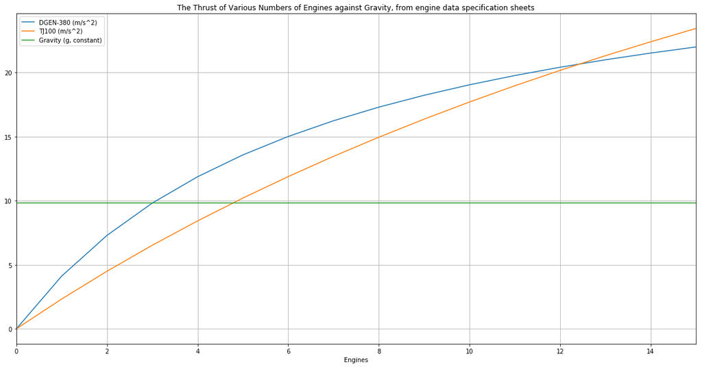

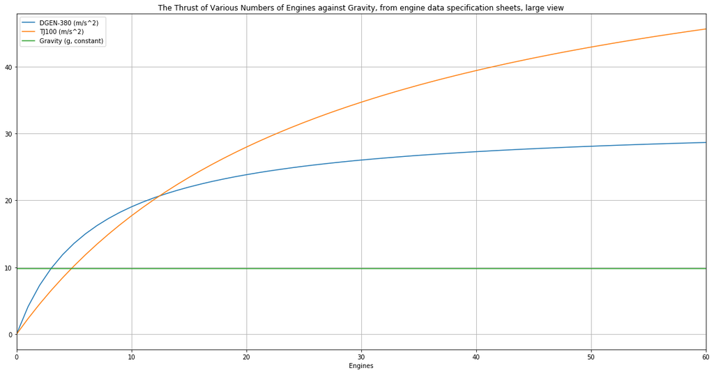

```python
# Created by Shaunak Gadkari, 2019

# This is a python program that will print out a line plot on data regarding how different numbers of engines help
# go against gravity
# NOTE: This code doesn't run on your computer, I ran it on mine and exported the results.

# First graph for specifically relevant data
# Import data from a CSV file
fight_against_gravity_data = pd.read_csv('data/08_engine_different_numbers_grav.csv')
# Plot a line graph, don't split into subplots, the x axis is "engines", the figure size is 10, 10 (a square), add gridlines and a title
fa_grav_line = fight_against_gravity_data.plot.line(subplots=False, x="Engines", figsize=(20,10), grid=True, title="The Thrust of Various Numbers of Engines against Gravity, from engine data specification sheets")

# Second graph for a comparision of the two engines' thrusts with different configurations (not specifically relevant)
# Import data from a CSV file
fight_against_gravity_data_large = pd.read_csv('data/09_engine_different_numbers_large.csv')
# Plot a line graph, don't split into subplots, the x axis is "engines", the figure size is 10, 10 (a square), add gridlines and a title
fa_grav_line_large = fight_against_gravity_data_large.plot.line(subplots=False, x="Engines", figsize=(20,10), grid=True, title="The Thrust of Various Numbers of Engines against Gravity, from engine data specification sheets, large view")
```

## How/where will fuel be stored?

### Outline

This question required multiple considerations, such as weight distribution and average fuel consumption across the entire track. This led into sub-questions such as how much fuel will be needed or where it could be placed into the chassis to make it evenly distributed.

### How much fuel will be needed?

To answer this question, we should calculate the total fuel use of all engines:

- DGEN-380 $*$ 6: $102.564103 * 6 = 615.38kg/hr$

After this, we have to calculate how long the engines will be in use. A F1 race has to last for 305 kilometres. Since we have fuel measurements in kg/hr, we should calculate how long it will take the car to go that distance. The acceleration displacement formula can help us with this, but it first has to be modified to be solvable for t (orig. velocity is assumed as 0):

$$t=\sqrt{\frac{2d}{a}}$$

$d$ is distance and $a$ is acceleration. We can substitute these in:

$$t=\sqrt{\frac{2(305000)}{15}}$$$$t=\sqrt{\frac{610000}{15}}$$$$t=\sqrt{40666.67}$$$$t=201.66$$

This value is obviously wrong, because it assumes that their is no air and we are accelerating constantly. To get a more accurate value, we should work out the drag force using the below formula (this also means that we will have to calculate this twice, once for upwards acceleration and once for lateral):

$$F_{drag} = CpAv^2/2$$

where:  
p = fluid density  
C = drag coefficient  
A = presented area  
v = velocity

$$F_{drag} = CpAv^2/2$$

where:  
p = 1.225  
C = 0.012  
A = 0.500  
v = Variable

I have made a plot that shows lateral drag force with changing velocity:

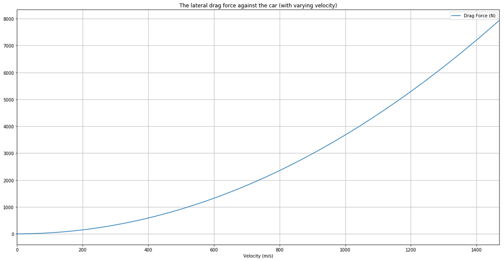

```python
# Created by Shaunak Gadkari, 2019

# This is a python program that will print out a line plot on data relating to lateral drag force
# NOTE: This code doesn't run on your computer, I ran it on mine and exported the results.

# First graph for specifically relevant data
# Import data from a CSV file
lat_drag_data = pd.read_csv('data/10_lateral_drag_changing_velocity.csv')
# Plot a line graph, don't split into subplots, the x axis is "velocity", the figure size is 20, 10, add gridlines and a title
lat_drag_line = lat_drag_data.plot.line(subplots=False, x="Velocity (m/s)", figsize=(20,10), grid=True, title="The lateral drag force against the car (with varying velocity)")
```

### How and where will this fuel be stored?

The next step now is to divide the fuel between the wings and chassis. A ratio that should allow the wings to be light enough is 1:8:1 (left wing:chassis:right wing). When using the fuel weight of 600kg, this becomes 60kg:480kg:60kg, corresponding to 86L:686L:86L.

## Materials Analysis

### Considerations

The materials used in this project will have to meet specific requirements in order for the car to be able to fly. These requirements mainly includes:

#### Weight

This requirement is everything when building a flying craft because weight is a very controlled resource. As time is money, weight is fuel because more weight requires more thrust and therefore more fuel to carry and for the aircraft to operate. I have taken into consideration weight in almost every part of their aircraft's design.

#### Strength

All aircraft, especially winged aircraft are expected to go under significant stress while flying. The air does not sit still but constantly batters the craft, putting pressure in the wings and therefore the fuselage. Hail may crack glass or even the pressure vessel which could be devestating for both the occupant and the outcome of the race. Not to mention, the people inside depend on the strength of the aircraft for their lives. If it crashes, the aircraft must handle it with a combination of crumple zones and reinforced areas that will do their best to make sure the people inside survive.

#### Suitability

This category is an umbrella that consists of many things. For example, can the material be welded onto the aircraft or will it have to be screwed? This could impact aerodynamic flow as well as strength. Is the material conductive to heat or electricity? This could be important when dealing with heat dissapation but also with the delicate circuitry inside, it only take a spark to ignite the fuel. Speaking of fuel, with the fuel tanks be corroded by it? Can they withstand the heavy liquid moving around as the aircraft turns? These are all important questions and they relate to the suitability of the aterial when used in a craft such as the one being discussed.

### Choices

#### Wings

For the wings, I have decided to use carbon fibre. Not only is carbon fibre light, with a density of [Source 10] 2 grams per cubic centimetre, it is a strong material that can take the harsh conditions of the wings. They will be bent and pushed around by strong winds when flying. Additionally, the wings will have to be hollow to hold fuel and hydraulic assemblies.

#### Nose cone

For the nose cone, I have chosen to use an aluminium sheet over plastic. The aluminium will smooth the surface and protect it from impacts while the plastic will be extremely lightweight because the nose cone does not have to be that strong, only aerodynamic in nature. This is perfect for plastic as it is very mouldable and afterwards, a 1-3 mm aluminium sheet will cover it, protecting it while keeping its lightweight nature. The plastic also protects from lightning. The aluminium will hopefully attract lightning and dissapate it over the fuselage while the nonconductive plastic will keep the human inside the cockpit/capsule safe. Of course, these protections do not apply to the windshield.

#### Windshield

There is a windshield in the nosecone that will be made of a outside layer specially reinforced tempered glass, with a sticky resin-like glue substance in the middle and then another layer of glass on the inside. Although this sounds strange, this is how the windshield in most cars is constructed. In the event that the windshield is heavily broken, the sticky substance (which is clear as so not to impede visibility) will hold on the glass shards and stop them shattering all over the pilot.

#### Tail Bridge

The tail bridge will be made out of thick but hollow aluminium. Although it is heavy, the tail bridge need to be able to enact torque on the entire craft because on the back it has elevators that control the aircraft's pitch.

#### Elevators, Ailerons and Rudder

The elevators and ailerons will be made out of solid carbon fibre. They will be thin and non moving so it is just helpful to have them as light as possible to the mechanisms can hold them against the wind when yawing, pitching or rolling the aircraft.

#### Main Chassis

The main chassis will be made out of a thin aluminium hull (perhaps 2cm thick). This will protect from impacts while still keeping space inside for fuel and the engine assemblies.

#### Wheels and Tyres

The wheels and tyres on the bottom will be experimental and made out of carbon fibre. The reason for this is carbon fibre is a light material that will help the craft fly better. It will also be better for the hydraulic assemblies to retract the wheels if they are lighter than heavier. Although in a normal car carbon fibre wheels would be incredibly inefficient because they do not respond well to repetitive use, my design would work with them because the wheels are not providing any power, they are simply a medium to touch the ground. This means that there would be no need for much traction with the ground and the wheels could last for much longer.

## Assembly

### Considerations

The considerations made when choosing how the craft would work were based on a limited number of factors:

- Efficiency - the mechanism should run quickly and 'quitely' - with minimum maintainence required.
- Suitability - the mechanism should acheive its desired task

### Parts

#### Nosecone

The nosecone is not made out of any special parts, simply the materials described in the section above. After a insulating and protecting layer, there is a cockpit with a seat in which the pilot can monitor and control the different systems of the aircraft. There will be a standard aircraft yoke that will control the ailerons and the elevators, with pedals that control the rudder, or in the case of ground driving, the steering wheel.

#### Elevators, Ailerons and Rudder

These undergo 2 states: flying and ground. In flying mode, they are under the control of the pilot, like in a normal aircraft. However, during ground mode, they are optimised to provide traction with the ground. The ailerons, which would usually control roll, are directing air up so as to keep the craft on the ground. The rudder is dampened to avoid severe movement but moves along with the ground pedals and the wheels to help with turning. The elevators are very slightly angled downwards at all times, but not too much as they are not in the center of the craft like the ailerons and so might cause it to pitch up or down. All in all, during ground operation, the systems work together to provide maximum traction for the vehicle.

#### Engine Assemblies

The engines are able to be moved in a hemi-sphere which allows them to direct thrust as the pilot wills it. The bottom engines will mainly work in lateral and VTOL positions, but the top engines provide traction to the wheels during ground movement as well as extra speed. It is important to note that the top engines CANNOT be used to power the aircraft directly upwards, this would burn or melt the fuselage.

#### Wing Design

The wings are an integral part of the aircraft's design. This is because of the folding feature that in intergrated into them. If it is required during ground flight, fuel will drain to the main chassis, mechanics will be retracted and the entire wing assembly will fold vertically, like a piece of paper. This will help in reducing the form factor of the aircraft as well as stopping unwanted upwards movement during ground flight.

# Assessment

## Self Assessment

### CRITERION: Create and label a detailed design of my own Flying F1 car and describe how the vehicle flies using appropriate scientific language (e.g. thrust, lift etc.)

I was able to do this very well throughout the report. This was represented in areas such as the fuel calculations, drag calulations and the various graphs that were generated throughout the report.

### CRITERION: Explain how key design features enhance aerodynamics using appropriate scientific language

I was able to do this very well during the drag force and acceleration calculations. My working was aided by the graphs that I created.

### CRITERION: Evaluate design ideas, processes and solutions against comprehensive criteria\

I showed this when I made considerations and criteria for almost every aspect of the design of the flying car. I was able to do it very well.

### CRITERION: Identify, explain, analyse and reflect on my own and others thinking processes

I did this very well when I went through various designs and methods for creating the car and discounted ones that would not be efficient.

### Which activities challenged your thinking?

I was challenged by almost all the activities because I had never gone into this much depth on a report before. When I was doing calculations for drag force and acceleration, I was challenged because I had not used those formulae before, even in maths. When I generated the graphs using Python, I had to research how to use it and the different types of graphs available to me. This showed me that the tool was very powerful and I could use it to my advantage. One thing that I was not challenged by was creating the actual data that the graphs used because I made it in Excel which I have some practice at using due to regular science and Maths Modelling in Semester 1.

### What new learnings or understandings have you gained from the Challenge?

As I stated before, I gained an understanding of various mathematical formulae used in both aerodynamics and acceleration calculations. This included the drag force equation which could be helpful in other projects, not only in Research Science but in maths or core science. I learned how to generate graphs and plots using Python and embedded packages and also how to use Jupyter Notebook, a tool that could help me with reports even in university.

## Peer Assessment (Assesor: Joshua Chua)

### CRITERION: Create and label a detailed design of my own Flying F1 car and describe how the vehicle flies using appropriate scientific language (e.g. thrust, lift etc.)

Included in the document is a diragram that contains clearly labelled detailing the parts of the Flying F1 Car. During the report it is described how numerous engines will gerante enough thrust to create lift.

### CRITERION: Explain how key design features enhance aerodynamics using appropriate scientific language

The report included details about the nose cone and how it enhance aerodynamic and streamlined to create a more effecient flgiht travel. It also included details about projected area and how it was taken into account while making the key design features.

### CRITERION: Evaluate design ideas, processes and solutions against comprehensive criteria

Aspects of the criteria showed that there were many design ideas evaluated and they were discounted or implemented by their suitability in the project.

### CRITERION: Identify, explain, analyse and reflect on my own and others thinking processes

The report included justification for the design as well aso a reflection on the thinking processes that went into the design of the vehicle.

# Diagrams

## Diagram 1

[figure not shown]

# Sources

### General

1. Engheim, E. (2019). Most Interesting Rocket Engines. Medium. Available at: https://medium.com/@Jernfrost/most-interesting-rocket-engines-93b01af7ae4c [Accessed 23 Jul. 2019].
2. Rafailov, Y. (2004). Acceleration That Would Kill a Human - The Physics Factbook. [online] Hypertextbook.com. Available at: https://hypertextbook.com/facts/2004/YuriyRafailov.shtml [Accessed 23 Jul. 2019].
3. Urbonas, J., Gresty (Dr.), M., Vitkauskas, P., Valiūtė, A. and Ellis, W. (2019). "Death by Rollercoaster" - The Euthanasia Coaster. [online] YouTube. Available at: https://youtu.be/eKmKLZOAT38 [Accessed 23 Jul. 2019].
4. McDermott, A. (2019). F1 circuits and F1 calendar for the 2019 GP season. [online] BWin News. Available at: https://sports.bwin.com/en/news/other-sports/f1/f1-circuits-grand-prix-calendar [Accessed 26 Jul. 2019].
5. wikipedia.org. (2019). List of Formula One circuits. [online] Available at: https://en.wikipedia.org/wiki/List_of_Formula_One_circuits [Accessed 26 Jul. 2019].
6. Cooper, A. (2019). F1 set to introduce minimum driver weight in 2019. [online] au.motorsport.com. Available at: https://au.motorsport.com/f1/news/fia-minimum-driver-weight-2019-halo-997615/1387540/ [Accessed 26 Jul. 2019].
7. Wikimedia Foundation (2019). Formula One car. [online] en.wikipedia.org. Available at: https://en.wikipedia.org/wiki/Formula_One_car [Accessed 26 Jul. 2019].
8. Wikimedia Foundation (2019). Jet fuel. [online] en.wikipedia.org. Available at: https://en.wikipedia.org/wiki/Jet_fuel. [Accessed 26 Jul. 2019]
9. Zona Land Education. (2019). Displacement, Acceleration Algebra. [online] Available at: http://zonalandeducation.com/mstm/physics/mechanics/kinematics/EquationsForAcceleratedMotion/AlgebraRearrangements/Displacement/DisplacementAccelerationAlgebra.htm [Accessed 27 Jul. 2019].
10. Dexcraft Inc. (2018). Aluminium vs carbon fibre in constructioon. [online]. Available at: http://www.dexcraft.com/articles/carbon-fiber-composites/aluminium-vs-carbon-fiber-comparison-of-materials/ [Accessed 15th August]
11. Engineering Toolbox (2015). Calculating drag force. [online]. Available at: https://www.engineeringtoolbox.com/drag-coefficient-d_627.html. [Accessed 15th August 2019]
12. Wikipedia (2019). Carbon fibres. [online]. Available at: https://en.wikipedia.org/wiki/Carbon_fibers. [Accessed 20th August 2019]
13. PYDATA.ORG (2019). Python Data Analysis Library. [online] Available at: https://pandas.pydata.org/ [Accessed 26th July 2019]

### Jet Engine Spec Sheets

1. PBS Group (2017). TJ23U TurboJet Engine. [online] PBS.CZ. Available at: https://www.pbs.cz/getmedia/660edbb9-4b1c-4484-8db0-534a71b39255/PBS_Turbojet-engine_TJ23U_EN.pdf [Accessed 24 Jul. 2019].
2. PBS Group (2017). TJ40-G1 Jet Engine. [online] PBS.CZ. Available at: https://www.pbs.cz/getmedia/e47db2ca-b200-43e8-a2e8-ebd4820fad86/PBS_Turbojet-engine_TJ40-G1_EN.pdf [Accessed 24 Jul. 2019].
3. PBS Group (2017). TJ40-G2 Jet Engine. [online] PBS.CZ. Available at: https://www.pbs.cz/getmedia/fc676eb2-eb2a-4ffb-a7ac-364a83606a06/PBS_Turbojet-engine_TJ40-G2_EN.pdf [Accessed 24 Jul. 2019].
4. PBS Group (2017). TJ100 Jet Engine. [online] PBS.CZ. Available at: https://www.pbs.cz/getmedia/3bf0621d-4146-4c90-b8d0-08a875fe6380/PBS_Turbojet-engine_TJ100_EN.pdf [Accessed 24 Jul. 2019].
5. PBS Group (2017). TJ150 Jet Engine. [online] PBS.CZ. Available at: https://www.pbs.cz/getmedia/27d922e1-9402-4b7a-b279-9e0f6517c190/PBS_Turbojet-engine_TJ150-_EN.pdf [Accessed 24 Jul. 2019].
6. PBS Group (2017). TJ80 Jet Engine. [online] PBS.CZ. Available at: https://www.pbs.cz/getmedia/6633e7f5-4e37-47e4-9f61-1f93ed7a4ac5/PBS_Turbojet-engine_TJ80_EN.pdf [Accessed 26 Jul. 2019].
7. Minijets FR Inc. (2019). DGEN-380 Turbofan Engine. [online]. MINIJETS.ORG. Available at: https://minijets.org/fr/300-500/price-induction-dgen-380-390/ [Accessed 6th August 2019]
8. Wikimedia Foundation (2019). Williams FJ33 Engine. [online]. wikipedia.org. Available: https://en.wikipedia.org/wiki/Williams_FJ33. [Accessed 5th August 2019]